# Exploring the BRFSS data

```r
cor(nSleep, nPhys, use="complete.obs")
```

```
## [1] -0.07839386
```

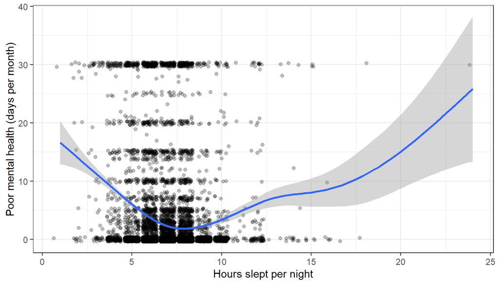

```r
# PLOT MENTAL
ggplot(brfss2013, aes(x=sleptim1, y=menthlth)) +
 theme_bw() +
  geom_jitter(alpha=0.25) +
   geom_smooth() +
    labs(x="Hours slept per night", y="Poor mental health (days per month)")
```

```r
cor(nSleep, nMntl, use="complete.obs")
```

```
## [1] -0.1270602
```

**Summary**

Initial Question: Does a correlation exist between the hours slept each night and reported days with poor physical health or poor mental health in the last 30 days?

Narrative from the Exploratory Analysis: There is no linear relationship between hours slept and the two variables. However there is a significant dip in the lowess regression line, implying that people on both extremes of the spectrum might have higher number of days with poor physical health or poor mental health.

**Research quesion 2:**

```r
dat2 <- allprep( educa, income2)
dat2$educa <- plyr::revalue(dat2$educa, c("Never attended school or only kindergarten" = "None/Kinder Only",
                                          "Grades 1 through 8 (Elementary)" = "1st-8th",
                                          "Grades 9 though 11 (Some high school)" = "9th - 11th",
                                          "Grade 12 or GED (High school graduate)" = "12th or GED",
                                          "College 1 year to 3 years (Some college or technical school)" = "Some college/Tech School",
                                          "College 4 years or more (College graduate)" = "College Graduate"))


sum2 <- dat2 %>%
    group_by(income2, educa) %>%
    summarize(Sum = n()) %>%
    spread(educa, Sum) %>%
    mutate()
colnames(sum2)[1] <- "Income"
pandoc.table(sum1,caption="Summary Statistics for income by education level", justify = "center")
```

[output not shown]

[output cut: 32 more lines]

[output not shown]

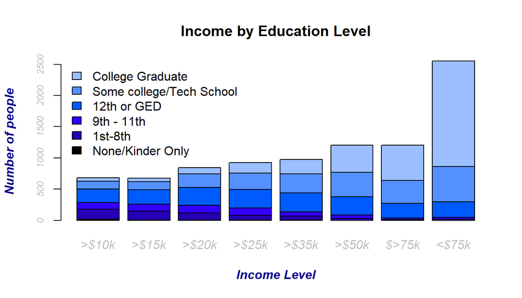

```r
counts <- table(dat2$educa, dat2$income2)
barplot(counts,
        main="Income by Education Level",
        ylab = "Number of people",
        xlab = "Income Level", col=c("black","#2500B6", "#3300FF", "#005BFF","#5491FF", "#9BBFFF"),
        font.axis = "3",
        col.axis = "gray",
        cex.axis = ".75",
        font.lab = "4",
        col.lab = "dark blue",
        names.arg=c(">$10k",">$15k",">$20k",">$25k",">$35k", ">$50k", "$>75k", "<$75k"),
        legend = TRUE, args.legend=(list(bty="n",x="topleft", ncol =1)))
```

This stacked bar plot visualizes the summary table and shows the amount of people within each income level based on their education level. It can be clearly seen from the graph that college graduates ( indicated by the lightest blue ) tend to earn more than $75,000.

**Summary**

Initial Question: Does having a better education potentially increase ones income level?

Narrative from the Exploratory Analysis: Yes, College Graduates make up the majority of $75k or more group, and over half of College Graduates make $75k or more. In fact, the number of college graduates increases each the Income Level increases.The data also shows that as Income Level increases, the amount of people with an education level lower than 12th or GED decreases.

**Research quesion 3:**

```r
nSmok = as.numeric(brfss2013$smokday2)
nDrnk = as.numeric(brfss2013$drnk3ge5)
dat3 <- allprep(drnk3ge5,exerhmm1, smokday2)%>%
  filter(exerhmm1 < 601 & exerhmm1 > 61)
```

*NOTE: Removing data where exercise is greater than 600 as there are very few people who exercised this often, as well as removed people who did not exercise at least an hour. This way graphs become easier to read since it allows us to focus on the bigger pieces of data.

```r
sum3 <- dat3 %>%
    group_by(drnk3ge5, exerhmm1) %>%
    summarize(Sum = n()) %>%
    spread(exerhmm1, Sum) %>%
    mutate()
colnames(sum3)[1] <- "Days Binge Drinked"
pandoc.table(sum3,caption="Summary Statistics for days binge drinked and hours excericed in the last month.")
```

```
##
## --------------------------------------------------------------------------------
##  Days Binge Drinked   100   110   115   120   125   130   145   200   230   250
## -------------------- ----- ----- ----- ----- ----- ----- ----- ----- ----- -----
##          0            175   NA     8     1     1    38     3    42     8     1
##
##          1            26    NA    NA    NA    NA     7     1     5    NA    NA
##
##          2            19     1     2    NA    NA    10     1     7    NA    NA
##
##          3             7    NA    NA     1    NA     2    NA     3    NA    NA
##
##          4            10    NA    NA    NA    NA     3    NA     1    NA    NA
##
##          5             9    NA    NA     1    NA     1    NA    NA    NA    NA
##
##          6             2    NA    NA    NA    NA     2    NA     1    NA    NA
##
##          8            NA    NA    NA    NA    NA     2    NA     2    NA    NA
##
##          9            NA    NA    NA    NA    NA    NA    NA     1    NA    NA
##
##          10            4    NA    NA    NA    NA     2    NA     3    NA    NA
##
##          12            4    NA    NA    NA    NA     2    NA     1    NA    NA
##
##          13            1    NA    NA    NA    NA    NA    NA    NA    NA    NA
##
##          15            2    NA    NA    NA    NA    NA    NA    NA    NA    NA
##
##          20           NA    NA    NA    NA    NA    NA    NA     1    NA    NA
##
##          23           NA    NA    NA    NA    NA     1    NA    NA    NA    NA
##
##          26           NA    NA    NA    NA    NA    NA    NA    NA    NA    NA
##
##          30            3    NA    NA    NA    NA    NA    NA     2    NA    NA
## --------------------------------------------------------------------------------
##
## Table: Summary Statistics for days binge drinked and hours excericed in the last month. (continued below)
```

[output cut: 24 more lines]

```
##
##  NA    NA    NA    NA    NA    NA    NA
##
##  NA    NA    NA    NA    NA    NA    NA
##
##   1     1    NA    NA    NA    NA    NA
##
##  NA    NA    NA    NA    NA    NA    NA
##
##  NA    NA    NA    NA    NA    NA    NA
##
##  NA    NA     1    NA    NA    NA    NA
##
##   1    NA     2    NA    NA     1    NA
## -----------------------------------------
```

This summary table shows the relationship between days binge drinked and hours exercised, we can see that a lot of the people who are exercising are also not binge drinking.

```r
sum4 <- dat3 %>%
    group_by(smokday2, exerhmm1) %>%
    summarize(Sum = n()) %>%
    spread(exerhmm1, Sum) %>%
    mutate()
colnames(sum4)[1] <- "Frequency of days now smoking"
pandoc.table(sum4,caption="Summary Statistics for smoking habits and hours excericed in the last month")
```

```
##
## -------------------------------------------------------------------------------
##  Frequency of days now smoking   100   110   115   120   125   130   145   200
## ------------------------------- ----- ----- ----- ----- ----- ----- ----- -----
##            Every day             55    NA     1     1    NA     8    NA    20
##
##            Some days             39    NA     4    NA     1    19    NA    15
##
##           Not at all             168    1     5     2    NA    43     5    34
## -------------------------------------------------------------------------------
##
## Table: Summary Statistics for smoking habits and hours excericed in the last month (continued below)
##
##
## -----------------------------------------------------
##  230   250   300   330   400   402   430   500   600
## ----- ----- ----- ----- ----- ----- ----- ----- -----
##   1    NA    10     2    11    NA     2     4     1
##
##   2    NA     9     1     5    NA     1     3    NA
##
##   5     1    22     6    37     1     4     4     3
## -----------------------------------------------------
```

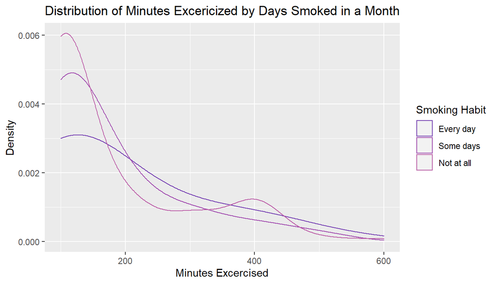

```r
ggplot(dat3, aes(x = exerhmm1, color = smokday2)) +
    geom_density(adjust = 2) +
    scale_color_manual(values = rev(heat_hcl(6, h = c(20,-80), l = c(75,40), c =c(40,80), power = 1))) +
    labs(title = "Distribution of Minutes Excericized by Days Smoked in a Month", y = "Density", x = "Minutes Excercised", col = "Smoking Habit") +
    theme(plot.title = element_text(hjust = 0.5))
```

We can see from the graph that while people who don’t smoke at all have a higher density for 100 minutes, they end up having the lowest density for 250 minutes, and rise back up at 400 minutes.

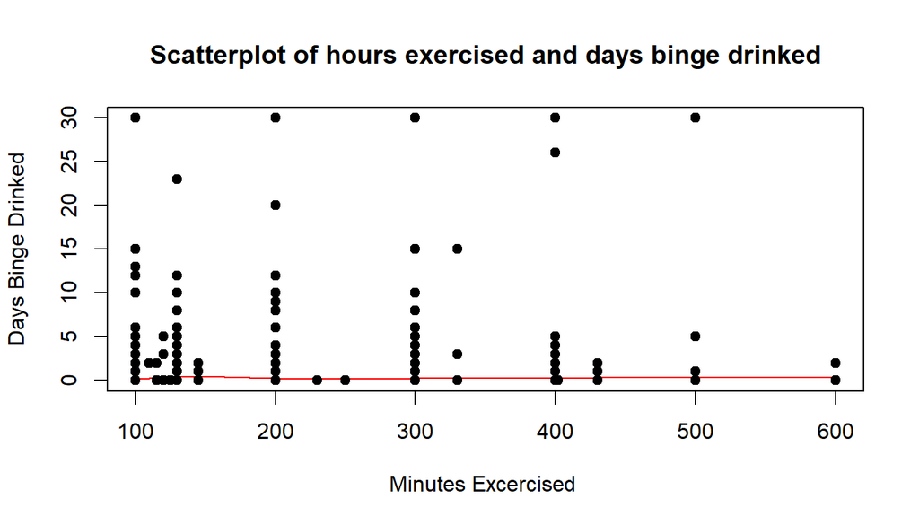

```r
plot(dat3$exerhmm1, dat3$drnk3ge5, main="Scatterplot of hours exercised and days binge drinked",
   xlab="Minutes Excercised ", ylab="Days Binge Drinked", pch=19, lines(lowess(dat3$exerhmm1, dat3$drnk3ge5), col = "red" ))
```

**Summary**

Initial Question: Is there a relation ship between minutes exercised and binge drinking and frequency of smoking?